# Capstone Project

Replicating “Intergenerational Mobility and Preferences for Redistribution” (AER 2018)

# Overview

The following capstone project replicates some of the key results from the paper “Intergenerational Mobility and Preferences for Redistribution” by Alberto Alesina, Stefanie Stantcheva, and Edoardo Teso (*American Economic Review* 2018). In their paper, Alesina, Stantcheva, and Teso explore how overly optimistic or pessimistic beliefs about intergenerational mobility (as measured by the difference between true and perceived mobility) is related to support for redistribution.

In this replication, you will reproduce three of the main tables and two figures, either in part or in whole. **You have 20 days to complete the replication exercise - it is due by the end of the day on March 28<sup>th</sup>.** During the replication, you are expected to work on your own - do not collaborate with other students. If you have devoted substantial time to a problem and are still in need of assistance, you may contact me for suitable hints. But please try to use the course materials, R help files, and online documentation to figure out the solutions yourself as much as possible. In the future, it is important that you’re able to troubleshoot problems and navigate resources in R on your own.

# Preliminaries

1. In your project folder for the course, create a new folder for the capstone exercise.
2. Download the paper and data for the paper from [here](https://www.aeaweb.org/articles?id=10.1257/aer.20162015) and store them in the capstone folder.
3. Within the capstone folder, create a new R Markdown file for the exercise that will produce an HTML file.
4. Set the following options for the document:
   - Set the data frame print method to “kable”.
   - Set the code highlighting to “zenburn”.
   - Set the theme to “readable”.
   - Set the document to use code folding, with the code hidden by default.
5. Reproduce the instructions in your RMarkdown document, with code entered between each instruction.
6. Be sure to commit and push your work to Github after each section AT A MINIMUM (hence, at least after “Preliminaries”, “Basic data set preparation”, “Table 1”,“Table 2”, “Table 3”, “Figure 2”, and “Figure 3”).

# Basic data set preparation

```r
# Load libaries
library(rio)
library(tidyverse)
library(broom)
library(knitr)
library(stargazer)
library(glue)
library(ggthemes)
```

1. Import the data file “Data_Descriptive_Waves_ABC.dta”.

```r
# Import data
base_data <- import("Data_Descriptive_Waves_ABC.dta")
```

2. Keep observations where *flag_1* and *flag_2* are equal to 0.

```r
# Filter for flag_1 and flag_2 equal to zero
base_data <- base_data %>% filter(flag_1 == 0, flag_2 == 0)
```

3. Generate a University indicator variable, as follows:
   - The variable should equal 1 when any of the following conditions hold:
     - *education* is greater than or equal to 6 and *US* is equal to 1.
     - *education* is greater than or equal to 6 and *UK* is equal to 1.
     - *education* is greater than or equal to 5 and *Italy* is equal to 1.
     - *education* is greater than or equal to 7 and *France* is equal to 1.
     - *education* is greater than or equal to 5, *Sweden* is equal to 1, and *wave* is equal to “September”.
     - *education* is greater than or equal to 6, *Sweden* is equal to 1, and *wave* is equal to “February”.
   - The variable should equal to NA_real_ (NA value specific to numeric values) if the value of education is missing.
   - Zero otherwise (if using a case_when function, you can do this by setting the last case to be “TRUE ~ 0”. )

```r
# Generate university indicator
base_data <- base_data %>% mutate(university = case_when(
  (education >= 6 & US==1) ~ 1,
  (education>=6 & UK==1) ~ 1,
  (education>=5 & Italy==1) ~ 1,
  (education>=7 & France==1) ~ 1,
  (education>=5 & Sweden==1 & wave=="September") ~ 1,
  (education>=6 & Sweden==1 & wave=="February") ~ 1,
  (is.na(education)) ~ NA_real_,
  TRUE ~ 0
))
```

4. Turn married into an indicator variable by recoding values of 2 for *married* to 0.

```r
# Turn married into indicator variable by recoding values of 2 for "married" to 0
base_data <- base_data %>% mutate(married = if_else(married == 2, 0, married))
```

22. Generate age bracket indicators as follows:
    - *age_1*, equal to 1 if age is between 18 and 29 (inclusive).
    - *age_2*, equal to 1 if age is between 30 and 39 (inclusive).
    - *age_3*, equal to 1 if age is between 40 and 49 (inclusive).
    - *age_4*, equal to 1 if age is between 50 and 59 (inclusive).
    - *age_5*, equal to 1 if age is greater than or equal to 60.

```r
# Generate Age Bracket Variables
base_data <- base_data %>% mutate(
  age_1 = if_else(age >= 18 & age <= 29, 1, 0),
  age_2 = if_else(age >= 30 & age <= 39, 1, 0),
  age_3 = if_else(age >= 40 & age <= 49, 1, 0),
  age_4 = if_else(age >= 50 & age <= 59, 1, 0),
  age_5 = if_else(age >= 60, 1, 0)
)
```

6. Generate a *country* variable, equal to:
   - “US” if *US* is equal to 1.
   - “UK” if *UK* is equal to 1.
   - “France” if *France* is equal to 1.
   - “Italy” if *Italy* is equal to 1.
   - “Sweden” if *Sweden* is equal to 1.

```r
# Generate Country Variable
base_data <- base_data %>% mutate(country = case_when(
  (US == 1) ~ "US",
  (UK == 1) ~ "UK",
  (France == 1) ~ "France",
  (Italy == 1) ~ "Italy",
  (Sweden == 1) ~ "Sweden"
))
```

# Table 1 - Summary Statistics

1. Begin by creating a summary statistics data frame, with averages for selected variables by country (with missing values removed when calculating the mean). Be sure to create new variable names that match the description in Table 1 of Alesina, Stantcheva, & Teso. The variables should be as follows:

   | Variables |  |
   | --- | --- |
   | age_1 | inc_bracket_3 |
   | age_2 | inc_bracket_4 |
   | age_3 | married |
   | age_4 | born_in_country |
   | age_5 | employed |
   | inc_bracket_1 | unemployed |
   | inc_bracket_2 | university |

```r
summary_data <- base_data %>% group_by(country) %>% summarize(
  "Male" = mean(male),
  "18-29 years old" = mean(age_1, na.rm = TRUE),
  "30-39 years old" = mean(age_2, na.rm = TRUE),
  "40-49 years old" = mean(age_3, na.rm = TRUE),
  "50-59 years old" = mean(age_4, na.rm = TRUE),
  "60-69 years old" = mean(age_5, na.rm = TRUE),
  "Income bracket 1" = mean(inc_bracket_1, na.rm = TRUE),
  "Income bracket 2" = mean(inc_bracket_2, na.rm = TRUE),
  "Income bracket 3" = mean(inc_bracket_3, na.rm = TRUE),
  "Income bracket 4" = mean(inc_bracket_4, na.rm = TRUE),
  "Married" = mean(married, na.rm = TRUE),
  "Native" = mean(born_in_country, na.rm = TRUE),
  "Employed" = mean(employed, na.rm = TRUE),
  "Unemployed" = mean(unemployed, na.rm = TRUE),
  "College" = mean(university, na.rm = TRUE)
)
```

2. Rearrange the summary statistics dataframe to look more like Table 1 in Alesina, Stantcheva, & Teso.
   - First, transpose the dataframe and convert it into a tibble - saving this to a new object.
   - Set the country variable from the original summary statistics data frame as the column names of the new tibble.
   - Remove the country names from the first row of the new tibble.
   - Define a new variable, called *Variable*, equal to the column names of the original summary data frame (except for the first element of the column names vector).
   - Rearrange the columns to match the layout of Table 1, by using the **select()** function.
   - Convert the variables *US*, *UK*,*France*,*Italy*, and *Sweden* in the summary tibble into numeric and then round the values to two digits (using the **round()** function). Be sure to vectorize the data type conversion and round functions.

```r
# Rearrange the Table
summary_data_2 <- t(summary_data) %>% as_tibble()
colnames(summary_data_2) <- summary_data$country
summary_data_2 <- summary_data_2[-1,]
summary_data_2$Variable <- colnames(summary_data)[-1]

## Use the Select Function to rearrange the columns to match column 1
summary_data_2 <- summary_data_2 %>% select(Variable,US, UK, France,Italy,Sweden)

# Turn the columns that should be numeric into numbers
summary_data_2[,c("US","UK","France","Italy","Sweden")] <-
  summary_data_2[,c("US","UK","France","Italy","Sweden")]  %>%
  map(as.numeric) %>%
  map(round,2)
```

3. Turn the work in part (ii) into a function, that takes a generic summary data frame and does the exact steps outlined above.

```r
# Turn Data Transformation Into a Function
transform_tab <-function(sum_obj){
  new_summary <- t(sum_obj) %>% as_tibble()
  colnames(new_summary) <- sum_obj$country
  new_summary <- new_summary[-1,]
  new_summary$Variable <- colnames(sum_obj)[-1]

  new_summary <- new_summary %>% select(Variable,US,UK,France,Italy,Sweden)
  new_summary[,c("US","UK","France","Italy","Sweden")] <-
    new_summary[,c("US","UK","France","Italy","Sweden")]  %>%
    map_df(as.numeric) %>%
    map_df(round,2)

  return(new_summary)

}
```

4. Transform the original summary data frame now using the function you’ve created instead. View the resulting tibble, replicating the summary statistics of Table 1.

```r
summary_data <- transform_tab(summary_data)
summary_data
```

| Variable | US | UK | France | Italy | Sweden |
| --- | --- | --- | --- | --- | --- |
| Male | 0.48 | 0.48 | 0.50 | 0.50 | 0.47 |
| 18-29 years old | 0.26 | 0.26 | 0.23 | 0.19 | 0.21 |
| 30-39 years old | 0.18 | 0.18 | 0.20 | 0.22 | 0.18 |
| 40-49 years old | 0.19 | 0.21 | 0.21 | 0.23 | 0.19 |
| 50-59 years old | 0.21 | 0.18 | 0.20 | 0.20 | 0.21 |
| 60-69 years old | 0.16 | 0.16 | 0.16 | 0.17 | 0.21 |
| Income bracket 1 | 0.16 | 0.31 | 0.31 | 0.27 | 0.33 |
| Income bracket 2 | 0.22 | 0.35 | 0.30 | 0.28 | 0.26 |
| Income bracket 3 | 0.23 | 0.11 | 0.14 | 0.18 | 0.22 |
| Income bracket 4 | 0.39 | 0.23 | 0.25 | 0.27 | 0.18 |
| Married | 0.51 | 0.47 | 0.44 | 0.55 | 0.41 |
| Native | 0.94 | 0.89 | 0.94 | 0.97 | 0.91 |
| Employed | 0.62 | 0.65 | 0.63 | 0.64 | 0.66 |
| Unemployed | 0.08 | 0.05 | 0.12 | 0.11 | 0.07 |
| College | 0.42 | 0.37 | 0.30 | 0.38 | 0.33 |

# Table 2 - Perceived and Actual Transition Probabilities

1. Begin by taking the basic data set and restricting it to keep only observations where *Treated* is equal to zero.

```r
table2_data <- base_data %>% filter(Treated == 0) %>% as_tibble()
```

2. Create a table 2 summary statistics data frame, with averages again computed by country and missing values excluded. The summary statistics should comprise the averages of the following variables (again with new variable names that match the formatting of Table 2 in the paper):

```r
table2 <- table2_data %>% group_by(country) %>% summarize(
  "Q1 to Q5" = mean(q1_to_q5, na.rm = TRUE),
  "Q1 to Q4" = mean(q1_to_q4, na.rm = TRUE),
  "Q1 to Q3" = mean(q1_to_q3, na.rm = TRUE),
  "Q1 to Q2" = mean(q1_to_q2, na.rm = TRUE),
  "Q1 to Q1" = mean(q1_to_q1, na.rm = TRUE)
)
```

3. Use your table rearrangement function to transform your table 2 summary data frame so that the variables are rows and the countries are columns.

```r
table2 <- transform_tab(table2)
```

4. Create a new variable *type* equal to “perceived”.

```r
table2 <- table2 %>% mutate(
  type = "perceived")
```

22. Import the actual probabilities from the csv file on the course website and convert it into a tibble.

```r
# Actual Probabilities (supplied)
actual <- matrix(c(7.8,12.7,18.7,27.7,33.1,
                   11.4,12.9,19.9,25.1,30.6,
                   11.2,12.8,23.0,23.8,29.2,
                   10.4,15.6,21.0,25.8,27.3,
                   11.1,17.3,21.0,23.8,26.7),
                 nrow=5, ncol=5, byrow=FALSE)
actual <- actual %>% as_tibble()
actual <- actual %>% mutate(
  Variable = table2$Variable,
  type = "actual"
)
actual <- actual %>% select(Variable, everything())
colnames(actual) <- colnames(table2)
export(actual, "actual.csv")
```

6. Append the actual probabilities to the perceived probabilities summary you create and then sort the resulting data frame by the variable *Variable* (in descending alphabetical order).
7. Display your data frame for Table 2

```r
table2 <- bind_rows(table2, actual) %>% arrange(desc(Variable))
table2
```

| Variable | US | UK | France | Italy | Sweden | type |
| --- | --- | --- | --- | --- | --- | --- |
| Q1 to Q5 | 11.72 | 9.97 | 9.10 | 10.14 | 9.21 | perceived |
| Q1 to Q5 | 7.80 | 11.40 | 11.20 | 10.40 | 11.10 | actual |
| Q1 to Q4 | 11.98 | 10.62 | 10.53 | 11.25 | 11.16 | perceived |
| Q1 to Q4 | 12.70 | 12.90 | 12.80 | 15.60 | 17.30 | actual |
| Q1 to Q3 | 22.32 | 19.39 | 21.51 | 21.87 | 24.52 | perceived |
| Q1 to Q3 | 18.70 | 19.90 | 23.00 | 21.00 | 21.00 | actual |
| Q1 to Q2 | 21.83 | 22.25 | 23.60 | 23.13 | 23.10 | perceived |
| Q1 to Q2 | 27.70 | 25.10 | 23.80 | 25.80 | 23.80 | actual |
| Q1 to Q1 | 32.16 | 37.77 | 35.26 | 33.61 | 32.00 | perceived |
| Q1 to Q1 | 33.10 | 30.60 | 29.20 | 27.30 | 26.70 | actual |

# Table 3 - Relation between Perceptions and Policy Preferences

## Prepare the data for analysis

1. Import the table 3 data from the file “Data_Experiment_Waves_BC.dta”.
2. Keep only the observations where *flag_1*, *flag_2*, and *Treated* all equal zero.

```r
table3_data <- import("Data_Experiment_Waves_BC.dta") %>%
  filter(flag_1 == 0, flag_2 == 0, Treated == 0)
```

3. Repeat the creation of the *country* variable for the table 3 data set

```r
# Repeat the creation of the country variable for the table 3 dataset
table3_data <- table3_data %>% mutate(country = case_when(
  (US == 1) ~ "US",
  (UK == 1) ~ "UK",
  (France == 1) ~ "France",
  (Italy == 1) ~ "Italy",
  (Sweden == 1) ~ "Sweden"
))
```

4. Generate political spectrum position indicators as follows:
   - *left*, equal to 1 if *ideology_economic* is equal to 1 or 2.
   - *right*, equal to 1 if *ideology_economic* is equal to 4 or 5.
   - *center*, equal to 1 if *ideology_economic* is equal to 3.

```r
# Generate political spectrum position indicators
table3_data <- table3_data %>% mutate(
  left = ifelse((ideology_economic ==1 | ideology_economic ==2), 1, 0),
  right = ifelse((ideology_economic ==4 | ideology_economic ==5), 1, 0),
  center = ifelse((ideology_economic==3), 1, 0)
)
```

```r
# Generate policy support indicators
table3_data <- table3_data %>% mutate(
  budget_opportunities = budget_education+budget_health,
  support_estate_45 = (estate_tax_support>=4),
  unequal_opp_problem_d = (unequal_opportunities_problem==4),
  tools_d = (tools_government >=2)
)
```

6. Rename the following policy support variables:
   - Rename *level_playing_field_policies* to *support_eq_opp_pol*
   - Rename *income_tax_bottom50* to *income_tax_bot50*

```r
# Rename policy support variables
table3_data <- table3_data %>% rename(
  support_eq_opp_pol = level_playing_field_policies,
  income_tax_bot50 = income_tax_bottom50
)
```

7. Generate an indicator for whether or not someone is “rich” (household income is above the 75<sup>th</sup> percentile for the country.)
   - First, create a summary data frame with a new variable *income_p75*, the 75th percentile of *household_income* by country. You may need to use the **quantile()** function with **summarize()**.
   - Then merge these values into the table 3 data frame.
   - Finally, create the *rich* indicator, equal to 1 if *household_income* is greater than the 75th<sup>th</sup> percentile of income.

```r
## First create a summary table with income_p75, the 75th percentile of household_income by country
## You should probably use the quantile() function with summarize to do so.
country_rich_levels <- table3_data %>% group_by(country) %>%
  summarize(income_p75 = quantile(household_income, probs = 0.75, na.rm = TRUE))

## Then murge in income_p75 into the main table 3 dataframe
table3_data <- table3_data %>% left_join(country_rich_levels, by = "country")

## Finally, create the *rich* indicator equal to 1 if household_income is greater than
## the 75th percentile level
table3_data <- table3_data %>% mutate(
  rich = ifelse((household_income > income_p75), 1, 0)
)
```

8. Generate the following further indicator variables:
   - *young*, equal to 1 if *age* is less than 45.
   - *moved_up*, equal to 1 if *job_prestige_father* is greater than 3.
   - *immigrant*, equal to 1 if *parents_born_in_country* is equal to zero.

```r
# Generate further indicators
table3_data <- table3_data %>% mutate(
  young = ifelse(age<45, 1, 0),
  moved_up = ifelse((job_prestige_father>3),1,0),
  immigrant = ifelse((parents_born_in_country==0), 1,0)
)
```

9. Create a *country_survey* variable, which is a concatenation of the *country* and *round* variables. Convert this variable so that it is a factor.

```r
# Generate a country_survey and turn it into a factor variable
table3_data <- table3_data %>% mutate(
  country_survey = as.factor(glue("{country} {round}"))
)
```

## Perform Table 3 Regressions

1. To reproduce Panels A and B Table 3:
   - Create four basic model specifications, with explanatory variables comprising the controls mentioned in the next step and primary explanatory variables as follows:
     1. **Panel A, Q1 to Q1 Specification:** The main explanatory variable should be the *q1_to_q1* variable.
     2. **Panel A, Q1 to Q5 Specification:** The main explanatory variable should be the *q1_to_q5* variable.
     3. **Panel B, Q1 to Q1 Specification:** The main explanatory variables should be *q1_to_q1* $\times$ *left*, *q1_to_q1* $\times$ *right*, and *q1_to_q1* $\times$ *center*.
     4. **Panel B, Q1 to Q5 Specification:** The main explanatory variables should be *q1_to_q5* $\times$ *left*, *q1_to_q5* $\times$ *right*, and *q1_to_q5* $\times$ *center*.
        - To specify just the interaction effect and exclude the main effects of interaction terms in panel B, use the interaction notation x:y instead of x*y (supposing x and y are interacted).
   - For every specification, include the following control variables:

     | Control Variables |  |
     | --- | --- |
     | country_survey | children_dummy |
     | left | rich |
     | right | university_degree |
     | male | immigrant |
     | young | moved_up |

   - For every specification, perform a separate regression for each of the following dependent variables (corresponding to the model titles of Table 3):

     | Dependent Variables |  |
     | --- | --- |
     | budget_opportunities | support_estate_45 |
     | support_eq_opp_pol | government_intervention |
     | unequal_opp_problem_d | budget_safetynet |
     | income_tax_top1 | income_tax_bot50 |
     | tools_d |  |

   - Save each of the regressions into a named regression object. You can either run perform these regressions using a for-loop, which is much more concise but more difficult, or manually write each of the 4 sets of 9 regressions. If you use a loop, you may need to use the **get()** function with the iterated dependent variables (and store the regressions in a list).
     - Here’s a short way:

     ```r
     # Create a vector of dependent variables and then use a for-loop to iterate
     # across them to perform each regression [you need to use get() for this].


     ## Vector of dependent variables
     dep <- c("budget_opportunities", "support_estate_45", "support_eq_opp_pol",
              "government_intervention", "unequal_opp_problem_d", "budget_safetynet",
              "income_tax_top1", "income_tax_bot50", "tools_d")

     # Table 3, Panel A:
     t3a_q1toq1 <- list()
     t3a_q1toq5 <- list()

     for(yvar in 1:length(dep)){
       t3a_q1toq1[[yvar]] <- lm(get(dep[yvar]) ~ q1_to_q1 + country_survey +
            left + right + male + young + children_dummy + rich + university_degree +
            immigrant + moved_up, data = table3_data)
       t3a_q1toq5[[yvar]] <- lm(get(dep[yvar]) ~ q1_to_q5 + country_survey +
            left + right + male + young + children_dummy + rich + university_degree +
            immigrant + moved_up, data = table3_data)
     }


     # Table 3, Panel B: Q1 to Q1
     t3b_q1toq1 <- list()
     t3b_q1toq5 <- list()

     for(yvar in 1:length(dep)){
       t3b_q1toq1[[yvar]] <- lm(get(dep[yvar]) ~ q1_to_q1:left + q1_to_q1:right +
                                  q1_to_q1:center + country_survey +left + right +
                                  male + young + children_dummy + rich +
                                  university_degree +immigrant + moved_up,
                                data = table3_data)
       t3b_q1toq5[[yvar]] <- lm(get(dep[yvar]) ~ q1_to_q5:left + q1_to_q5:right +
                                  q1_to_q5:center + country_survey +left + right +
                                  male + young + children_dummy + rich +
                                  university_degree + immigrant + moved_up,
                                data = table3_data)
     }
     ```

     - Now here’s the long, manual way:

     ```r
     # Table 3, Panel A Q1 to Q1 Regressions
     t3_a_q1_1 <- lm(budget_opportunities ~ q1_to_q1 + country_survey +
            left + right + male + young + children_dummy + rich + university_degree +
            immigrant + moved_up, data = table3_data)
     t3_a_q1_2 <- lm(support_estate_45 ~ q1_to_q1 + country_survey +
            left + right + male + young + children_dummy + rich + university_degree +
            immigrant + moved_up, data = table3_data)
     t3_a_q1_3 <- lm(support_eq_opp_pol ~ q1_to_q1 + country_survey +
            left + right + male + young + children_dummy + rich + university_degree +
            immigrant + moved_up, data = table3_data)
     t3_a_q1_4 <- lm(government_intervention ~ q1_to_q1 + country_survey +
            left + right + male + young + children_dummy + rich + university_degree +
            immigrant + moved_up, data = table3_data)
     t3_a_q1_5 <- lm(unequal_opp_problem_d ~ q1_to_q1 + country_survey +
            left + right + male + young + children_dummy + rich + university_degree +
            immigrant + moved_up, data = table3_data)
     t3_a_q1_6 <- lm(budget_safetynet ~ q1_to_q1 + country_survey +
            left + right + male + young + children_dummy + rich + university_degree +
            immigrant + moved_up, data = table3_data)
     t3_a_q1_7 <- lm(income_tax_top1 ~ q1_to_q1 + country_survey +
            left + right + male + young + children_dummy + rich + university_degree +
            immigrant + moved_up, data = table3_data)
     t3_a_q1_8 <- lm(income_tax_bot50 ~ q1_to_q1 + country_survey +
            left + right + male + young + children_dummy + rich + university_degree +
            immigrant + moved_up, data = table3_data)
     t3_a_q1_9 <- lm(tools_d ~ q1_to_q1 + country_survey +
            left + right + male + young + children_dummy + rich + university_degree +
            immigrant + moved_up, data = table3_data)

     # Table 3, Panel B Q1 to Q1 Regressions
     t3_b_q1_1 <- lm(budget_opportunities ~ q1_to_q1*left + q1_to_q1*right +
                       q1_to_q1*center + country_survey + left + right + male +
                       young + children_dummy + rich + university_degree +
                       immigrant + moved_up, data = table3_data)
     t3_b_q1_2 <- lm(support_estate_45 ~ q1_to_q1*left + q1_to_q1*right +
                       q1_to_q1*center + country_survey + left + right + male +
                       young + children_dummy + rich + university_degree +
                       immigrant + moved_up, data = table3_data)
     t3_b_q1_3 <- lm(support_eq_opp_pol ~ q1_to_q1*left + q1_to_q1*right +
                       q1_to_q1*center + country_survey + left + right + male +
                       young + children_dummy + rich + university_degree +
                       immigrant + moved_up, data = table3_data)
     t3_b_q1_4 <- lm(government_intervention ~ q1_to_q1*left + q1_to_q1*right +
                       q1_to_q1*center + country_survey +
                       left + right + male + young + children_dummy +
                       rich + university_degree +
                       immigrant + moved_up, data = table3_data)
     t3_b_q1_5 <- lm(unequal_opp_problem_d ~ q1_to_q1*left + q1_to_q1*right +
                       q1_to_q1*center + country_survey + left + right + male +
                       young + children_dummy + rich + university_degree +
                       immigrant + moved_up, data = table3_data)
     t3_b_q1_6 <- lm(budget_safetynet ~ q1_to_q1*left + q1_to_q1*right +
                       q1_to_q1*center + country_survey +  left + right + male +
                       young + children_dummy + rich + university_degree +
                       immigrant + moved_up, data = table3_data)
     t3_b_q1_7 <- lm(income_tax_top1 ~ q1_to_q1*left + q1_to_q1*right +
                       q1_to_q1*center + country_survey + left + right + male +
                       young + children_dummy + rich + university_degree +
                       immigrant + moved_up, data = table3_data)
     t3_b_q1_8 <- lm(income_tax_bot50 ~ q1_to_q1*left + q1_to_q1*right +
                       q1_to_q1*center + country_survey + left + right + male +
                       young + children_dummy + rich + university_degree +
                       immigrant + moved_up, data = table3_data)
     t3_b_q1_9 <- lm(tools_d ~ q1_to_q1*left + q1_to_q1*right + q1_to_q1*center +
                       country_survey +left + right + male + young + children_dummy +
                       rich + university_degree + immigrant + moved_up,
                     data = table3_data)
     ```

2. If you did not place the regression objects in lists in the previous step, place the regressions for each of the 4 specifications in their own list now.
3. Use stargazer with the each of the 4 lists to produce Panels A and B of Table 3. You will need to specify options for the stargazer function:
   - First, create a *table_columns* vector, using the following code to get the column titles as written in the paper:

     ```r
     table_columns <- c("Budget opp",
                     "Support estate tax",
                     "Support equality opp. policies",
                     "Government interv",
                     "Unequal opp. very serious problem",
                     "Budget safety net",
                     "Tax rate top 1",
                     "Tax rate bottom 50",
                     "Govt. tools")
     ```

   - Then use the following options in the stargazer function call (in quotes if appropriate):

     | Option | Value |
     | --- | --- |
     | type: | html |
     | object.names | FALSE |
     | style | aer |
     | omit.stat | all |
     | column.sep.width | 2pt |
     | font.size | footnotesize |
     | digits | 3 |
     | column.labels | table_columns |

   - Finally, you will also need to manually specify the values for the following options: *title*, *keep*, *covariate.labels*. Choose these such that the regressions looks like the respective panels of Table 3.

   ```r
   # Table 3, Panel A
   stargazer(t3a_q1toq1, type="html", header = FALSE, object.names=FALSE,
             dep.var.labels.include = FALSE,
             title = "Table 3: Panel A: Q1 to Q1",
             keep = c("q1_to_q1"),
             style = "aer", omit.stat = "all", column.sep.width = "2pt",
             font.size = "footnotesize", digits = 3,
             covariate.labels = c("Q1 to Q1"),
             column.labels =  table_columns
             )
   ```

   **Table 3: Panel A: Q1 to Q1**

   |  | Budget opp | Support estate tax | Support equality opp. policies | Government interv | Unequal opp. very serious problem | Budget safety net | Tax rate top 1 | Tax rate bottom 50 | Govt. tools |
   | --- | --- | --- | --- | --- | --- | --- | --- | --- | --- |
   |  | (1) | (2) | (3) | (4) | (5) | (6) | (7) | (8) | (9) |
   | Q1 to Q1 | 0.030*** | 0.000 | 0.004*** | 0.002** | 0.001*** | 0.013*** | 0.057*** | -0.035*** | -0.000 |
   |  | (0.007) | (0.000) | (0.001) | (0.001) | (0.000) | (0.005) | (0.012) | (0.007) | (0.000) |
   | *Notes:* | ***Significant at the 1 percent level. |  |  |  |  |  |  |  |  |
   |  | **Significant at the 5 percent level. |  |  |  |  |  |  |  |  |
   |  | *Significant at the 10 percent level. |  |  |  |  |  |  |  |  |

   |  | Budget opp | Support estate tax | Support equality opp. policies | Government interv | Unequal opp. very serious problem | Budget safety net | Tax rate top 1 | Tax rate bottom 50 | Govt. tools |
   | --- | --- | --- | --- | --- | --- | --- | --- | --- | --- |
   |  | (1) | (2) | (3) | (4) | (5) | (6) | (7) | (8) | (9) |
   | Q1 to Q5 | -0.044*** | 0.0002 | -0.004*** | 0.001 | -0.00002 | -0.011 | -0.041** | 0.060*** | -0.0001 |
   |  | (0.011) | (0.0005) | (0.001) | (0.001) | (0.0004) | (0.007) | (0.019) | (0.011) | (0.0004) |
   | *Notes:* | ***Significant at the 1 percent level. |  |  |  |  |  |  |  |  |
   |  | **Significant at the 5 percent level. |  |  |  |  |  |  |  |  |
   |  | *Significant at the 10 percent level. |  |  |  |  |  |  |  |  |

   ```r
   # Table 3, Panel B
   stargazer(t3b_q1toq1, type="html", header = FALSE, object.names=FALSE,
             dep.var.labels.include = FALSE,
             title = "Table 3: Panel B, Q1 to Q1",
             keep = c("q1_to_q1:left", "q1_to_q1:right","left", "right"),
             style = "qje", omit.stat = "all", column.sep.width = "1pt",
             font.size = "footnotesize", digits = 3,
             order = c("q1_to_q1:left", "q1_to_q1:right","left","right"),
             covariate.labels = c("Q1 to Q1 x left-wing",
                                  "Q1 to Q1 x right-wing",
                                  "Left-wing",
                                  "Right-wing"),
             column.labels =  table_columns
             )
   ```

   **Table 3: Panel B, Q1 to Q1**

   |  | Budget opp | Support estate tax | Support equality opp. policies | Government interv | Unequal opp. very serious problem | Budget safety net | Tax rate top 1 | Tax rate bottom 50 | Govt. tools |
   | --- | --- | --- | --- | --- | --- | --- | --- | --- | --- |
   |  | (1) | (2) | (3) | (4) | (5) | (6) | (7) | (8) | (9) |
   | Q1 to Q1 x left-wing | 0.030*** | 0.001** | 0.006*** | 0.004*** | 0.002*** | 0.020*** | 0.069*** | -0.041*** | 0.001 |
   |  | (0.011) | (0.0005) | (0.001) | (0.001) | (0.0004) | (0.008) | (0.020) | (0.011) | (0.0005) |
   | Q1 to Q1 x right-wing | 0.019 | -0.0004 | 0.003** | 0.003** | 0.001** | 0.003 | 0.039* | -0.033*** | -0.0004 |
   |  | (0.012) | (0.001) | (0.001) | (0.002) | (0.0005) | (0.008) | (0.021) | (0.012) | (0.0005) |
   | Left-wing | 1.410** | 0.128*** | 0.223*** | 0.139 | 0.067** | 0.885* | 2.191* | -0.652 | 0.034 |
   |  | (0.681) | (0.029) | (0.066) | (0.092) | (0.027) | (0.469) | (1.221) | (0.689) | (0.028) |
   | Right-wing | -1.161* | -0.051* | -0.329*** | -0.713*** | -0.056** | -0.769* | -1.487 | 1.423** | -0.057** |
   |  | (0.664) | (0.029) | (0.065) | (0.090) | (0.026) | (0.457) | (1.201) | (0.678) | (0.028) |
   | *Notes:* | ***Significant at the 1 percent level. |  |  |  |  |  |  |  |  |
   |  | **Significant at the 5 percent level. |  |  |  |  |  |  |  |  |
   |  | *Significant at the 10 percent level. |  |  |  |  |  |  |  |  |

   ```r
   stargazer(t3b_q1toq5, type="html", header = FALSE, object.names=FALSE,
             dep.var.labels.include = FALSE,
             title = "Table 3: Panel B, Q1 to Q5",
             keep = c("q1_to_q5:left", "q1_to_q5:right","left", "right"),
             style = "qje", omit.stat = "all", column.sep.width = "1pt",
             font.size = "footnotesize", digits = 3,
             order = c("q1_to_q5:left", "q1_to_q5:right","left","right"),
             covariate.labels = c("Q1 to Q5 x left-wing",
                                  "Q1 to Q5 x right-wing",
                                  "Left-wing",
                                  "Right-wing"),
             column.labels =  table_columns
             )
   ```

   **Table 3: Panel B, Q1 to Q5**

   |  | Budget opp | Support estate tax | Support equality opp. policies | Government interv | Unequal opp. very serious problem | Budget safety net | Tax rate top 1 | Tax rate bottom 50 | Govt. tools |
   | --- | --- | --- | --- | --- | --- | --- | --- | --- | --- |
   |  | (1) | (2) | (3) | (4) | (5) | (6) | (7) | (8) | (9) |
   | Q1 to Q5 x left-wing | -0.080*** | -0.001 | -0.006*** | -0.003 | -0.002*** | -0.013 | -0.054* | 0.060*** | -0.001 |
   |  | (0.018) | (0.001) | (0.002) | (0.002) | (0.001) | (0.013) | (0.032) | (0.018) | (0.001) |
   | Q1 to Q5 x right-wing | -0.009 | 0.001 | -0.002 | 0.002 | 0.001 | -0.003 | -0.001 | 0.039** | 0.0005 |
   |  | (0.019) | (0.001) | (0.002) | (0.003) | (0.001) | (0.013) | (0.034) | (0.019) | (0.001) |
   | Left-wing | 1.499*** | 0.159*** | 0.382*** | 0.411*** | 0.170*** | 1.076*** | 2.549*** | -0.868* | 0.089*** |
   |  | (0.471) | (0.020) | (0.046) | (0.064) | (0.018) | (0.324) | (0.837) | (0.471) | (0.020) |
   | Right-wing | -2.216*** | -0.095*** | -0.318*** | -0.544*** | -0.041** | -1.300*** | -2.862*** | 1.793*** | -0.050** |
   |  | (0.484) | (0.021) | (0.047) | (0.065) | (0.019) | (0.333) | (0.860) | (0.484) | (0.020) |
   | *Notes:* | ***Significant at the 1 percent level. |  |  |  |  |  |  |  |  |
   |  | **Significant at the 5 percent level. |  |  |  |  |  |  |  |  |
   |  | *Significant at the 10 percent level. |  |  |  |  |  |  |  |  |

# Figures

## Figure 2, Panel B: Actual and Perceived Mobility Across Countries

1. Create a data set for Figure 2, by modifying the basic data set to keep only the observations where *Treated* is equal to zero.

```r
# Get sample
figure2_data <- base_data %>% filter(Treated == 0)
```

2. Create a figure 2 summary statistics data frame, which computes the average by country for the following variables:
   - **Perceived Q1 to Q5 Transition Probability**: *q1_to_q5*
   - **True Q1 to Q5 Transition Probability**: *true_q1_to_q5*

```r
# Generate Average perceived and true probability of Q1 to Q5 transition
figure2_sum <- figure2_data %>% group_by(country) %>% summarize(
  perceived_q1_to_q5 = mean(q1_to_q5),
  true_q1_to_q5 = mean(true_q1_to_q5)
)
```

3. Recode the country variable so that:
   - Sweden is abbreviated to “SE”
   - Italy is abbreviated to “IT”
   - France is abbreviated to “FR”

```r
# Recode Country
figure2_sum <- figure2_sum %>% mutate(country = recode(country,
  "Sweden" = "SE",
  "Italy" = "IT",
  "France" = "FR"
))
```

4. Generate a scatterplot using text labels for country instead of points, with the following formatting:
   - The true Q1 to Q5 probability is on the x-axis, with range 6 to 12.
   - The perceived Q1 to Q5 probability is on the y-axis, with range 6 to 12.
   - Each data point (or rather text label) is colored according to *country*.
   - There is a dotted reference line, using **geom_abline()**, with an intercept of 0 and slope of 1.
   - Suitable titles are added for the overall graph and each axis.
   - The following annotations are added to the ggplot:

   ```r
   annotate(geom="text", x=7, y=10, label = "Optimistic") +
   annotate(geom="text", x=10, y=7, label = "Pessimistic")
   ```

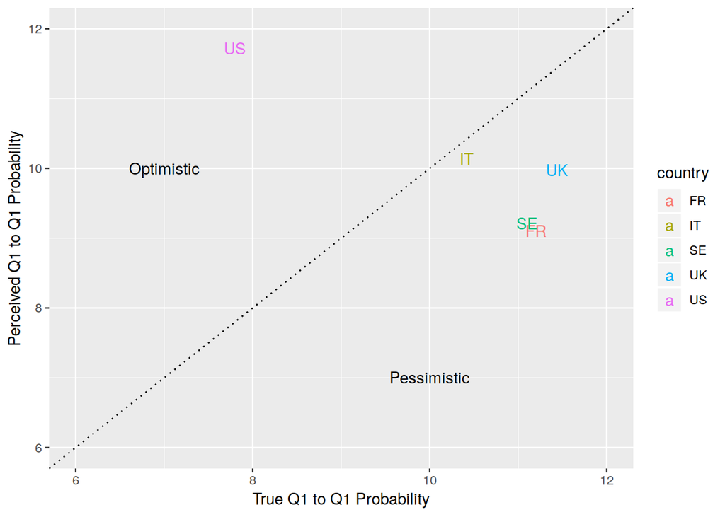

```r
# Generate text scatterplot
ggplot(figure2_sum,
       aes(x=true_q1_to_q5, y = perceived_q1_to_q5,
       label=country, col = country)) +
  geom_text() + xlim(6,12) + ylim(6, 12) +
  xlab("True Q1 to Q1 Probability") + ylab("Perceived Q1 to Q1 Probability") +
  geom_abline(intercept = 0, slope=1, linetype="dotted") +
  annotate(geom="text", x=7, y=10, label = "Optimistic") +
  annotate(geom="text", x=10, y=7, label = "Pessimistic")
```

## Figure 3 - Accuracy of Individual-Level Perceptions

1. Create a data set for Figure 3, by modifying the basic data set to keep only the observations where *Treated* is equal to zero. *q1_to_q1* is not equal to 100, and *q1_to_q5* is less than 80.

```r
# Take out outliers
figure3_data <- base_data %>% filter(Treated == 0, q1_to_q1 != 100,
                                     q1_to_q5 < 80)
```

2. Generate the following misperception variable:
   - *misperception_q1*, equal to the negative absolute value of *q1_to_q1* minus *true_q1_to_q1*
   - *misperception_q5*, equal to the negative absolute value of *q1_to_q5* minus *true_q1_to_q5*

```r
# Generate misperception variables
figure3_data <- figure3_data %>% mutate(
  misperception_q1 = -abs(q1_to_q1 - true_q1_to_q1),
  misperception_q5 = -abs(q1_to_q5 - true_q1_to_q5)
)
```

3. Generate two different data sets:
   - A *figure3_US* dataset, keeping only the observations where country is equal to *US* from the figure 3 dataset.
   - A *figure3_Europe* dataset, keeping only the observations where country is *not* equal to *US* from the figure 3 dataset.

```r
figure3_US <- figure3_data %>% filter(country == "US")
figure3_Europe <- figure3_data %>% filter(country != "US")
```

4. Use **ggplot** to reproduce the plots of the CDF of the negative absolute error between perceived and actual transition probabilities by country.
   - For each of the two graphs (US and Europe), plot both *misperception_q1* and *misperception_q5* by two seperate **stat_ecdf()** geometries to the same graph.
   - In each **stat_ecdf()**, you will need to specify the x-variable in the aesthetic, as well as ‘geom = “step”’ and a color to that particular ECDF. Choose ‘col = “blue”’ for *misperception_q1* and ‘col = “red”’ for *misperception_q5*.
   - For each graph, add a suitable overall title, axis titles, and set the range of the x axis to between -80 and 0.
   - Finally, apply the **theme_hc()** theme from **gg_themes()**.

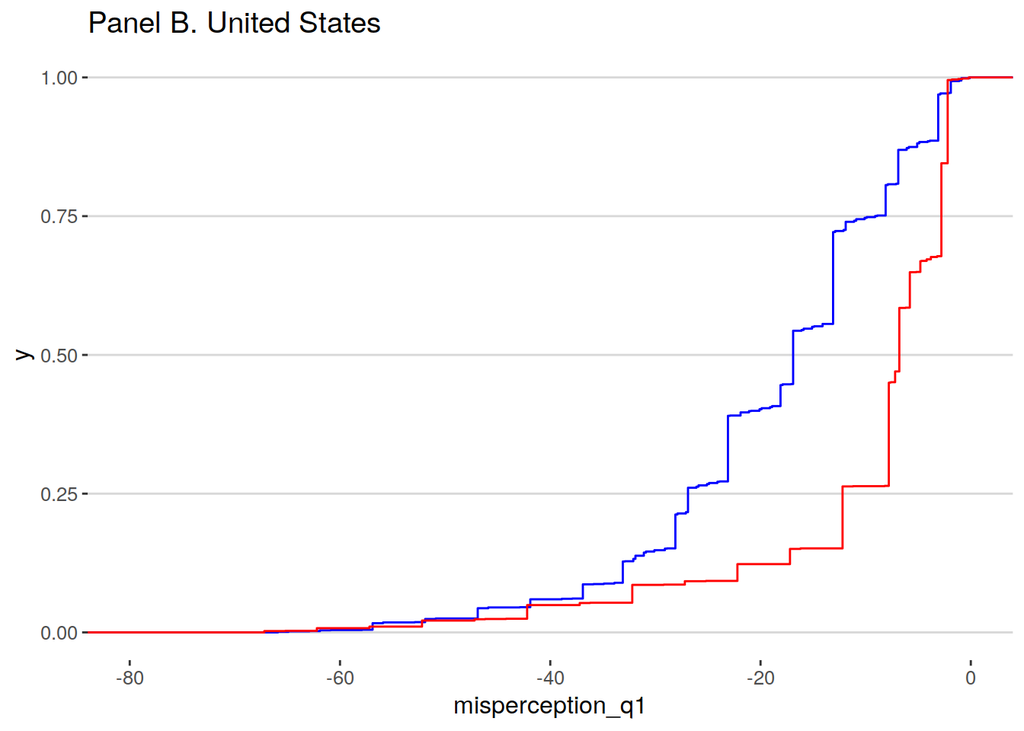

```r
 ggplot(figure3_US) + stat_ecdf(aes(x = misperception_q1),
                                geom = "step", col="blue") +
    ggtitle("Panel B. United States") +
  stat_ecdf(aes(x = misperception_q5),color ="red", geom = "step") +
  xlim(-80,0) + theme_hc()
```

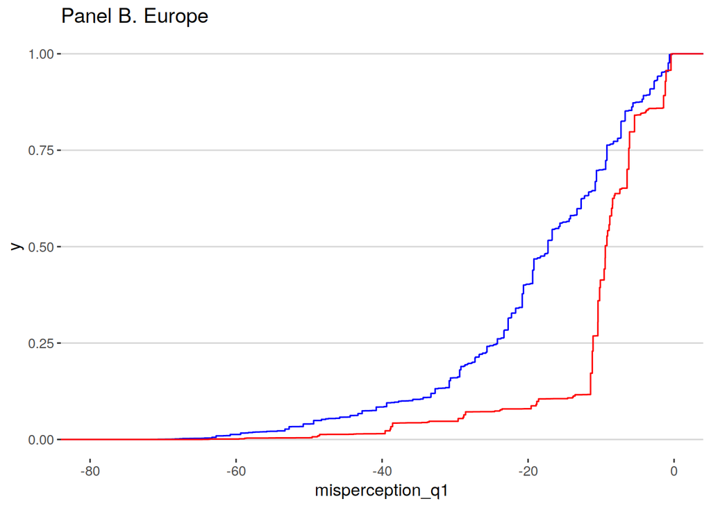

```r
  ggplot(figure3_Europe) + stat_ecdf(aes(x = misperception_q1),
                                     geom = "step", col="blue") +
  ggtitle("Panel B. Europe") +
  stat_ecdf(aes(x = misperception_q5),color ="red", geom = "step") +
  xlim(-80,0) + theme_hc()
```